# Liquidity Distribution AT

The composition of deposits of domestic non-MFI-sectors does not allow an insight about the evolution of government deposits from publicly available BSI-data. Such an information would provide insight whether increasing government deposits at the central bank had been withdrawn from accounts at commercial banks.

Banks# holdings of debt securities issued by non-domestic EA-residents shows a similar pattern as in the case of portfolio investment. In the period before the outbreak of the pandemic holdings of debt securities issued by domestic sectors impacted total holdings stronger than those issued by other EA-residents. In particular, the amount of debt securities issued by the domestic government had decreased by a large amount. The pace slowed with the outbreak of the pandemic and stagnated with the turn in monetary policy. The evolution of debt securities liabilities of credit institutions shows a similar pattern to the corresponding item in portfolio investment liabilities. However, the difference is that the latter includes all foreign countries as counterparts while BSI-data shows domestic sectors and other EA-residents as counterparts.

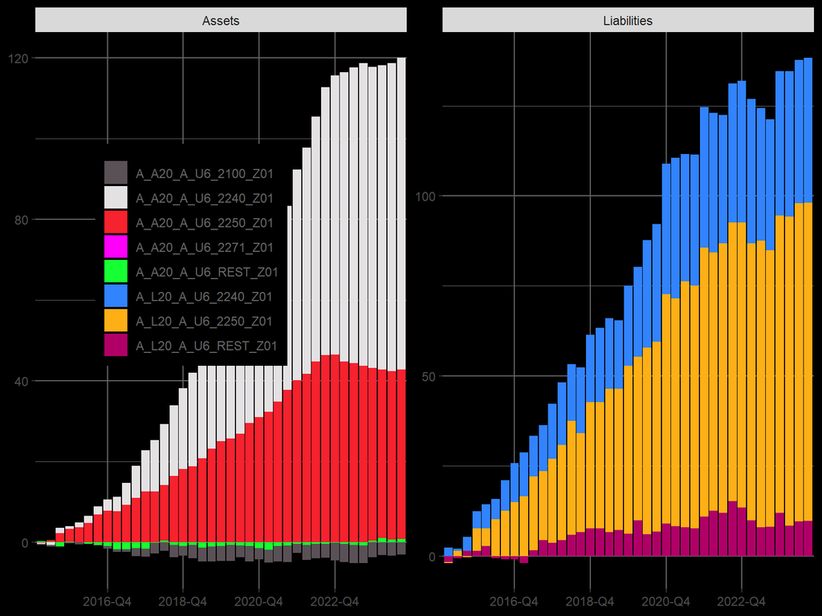

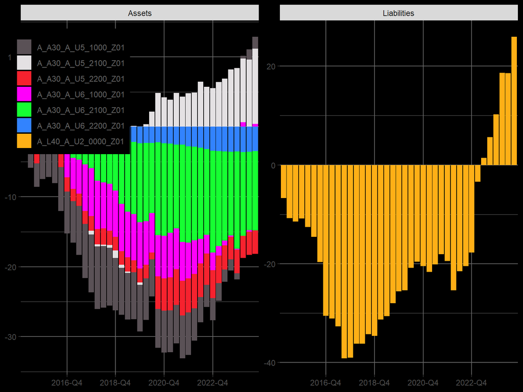